# Hierarchical Example

Although this file will knit to an html file, remember that you can run each chunk one at a time by clicking on the little green triangle. Knitting the whole document will take about 5 minutes.

## A quick look at the data

Our data is the `Exam` dataframe from the `mlmRev` package. You can read a little more about it by searching `Exam` in the help panel.

```r
Exam %>%
  glimpse()
```

```
## Rows: 4,059
## Columns: 10
## $ school   <fct> 1, 1, 1, 1, 1, 1, 1, 1, 1, 1, 1, 1, 1, 1, 1, 1, 1, 1, 1, 1, …
## $ normexam <dbl> 0.2613242, 0.1340672, -1.7238820, 0.9675862, 0.5443412, 1.73…
## $ schgend  <fct> mixed, mixed, mixed, mixed, mixed, mixed, mixed, mixed, mixe…
## $ schavg   <dbl> 0.1661752, 0.1661752, 0.1661752, 0.1661752, 0.1661752, 0.166…
## $ vr       <fct> mid 50%, mid 50%, mid 50%, mid 50%, mid 50%, mid 50%, mid 50…
## $ intake   <fct> bottom 25%, mid 50%, top 25%, mid 50%, mid 50%, bottom 25%, …
## $ standLRT <dbl> 0.6190592, 0.2058022, -1.3645760, 0.2058022, 0.3711052, 2.18…
## $ sex      <fct> F, F, M, F, F, M, M, M, F, M, M, M, M, M, M, F, F, M, M, F, …
## $ type     <fct> Mxd, Mxd, Mxd, Mxd, Mxd, Mxd, Mxd, Mxd, Mxd, Mxd, Mxd, Mxd, …
## $ student  <fct> 143, 145, 142, 141, 138, 155, 158, 115, 117, 113, 112, 137, …
```

Don’t worry about the R code for this plot.

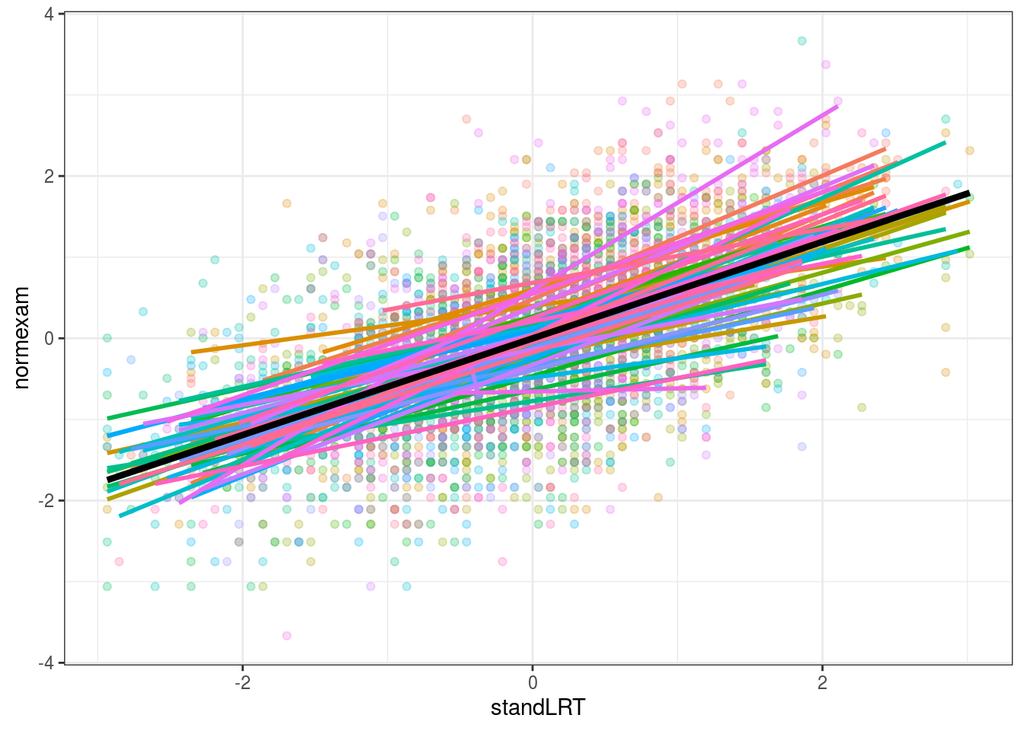

```r
Exam %>%
  ggplot(aes(standLRT, normexam)) +
  geom_point(aes(colour = school), alpha = .25) +
  geom_smooth(aes(colour = school), method = "lm", se = FALSE) +
  geom_smooth(method = "lm", se = FALSE, colour = "black", size = 1.5) +
  theme_bw() +
  theme(legend.position = "none")
```

## Fitting a model.

To fit a hierarchical model, we can add an intercept that varies by school by adding `(1 | school)` to the model. We want to add both a varying slope and intercept—we can do that by adding `(1 + stndLRT | school)` to the model. (As it turns out, if there’s any term in the model in addition to the intercept you don’t need the intercept, so you can write just `(stndLRT | school)`.)

Also, we change the function from `stan_glm()` to `stan_glmer()`.

The code chunk below will take several minutes to run.

```r
exam_hier <- stan_glmer(normexam ~ standLRT  + (standLRT | school), data = Exam)
```

## Fir diagnostics

These trace plots look good:

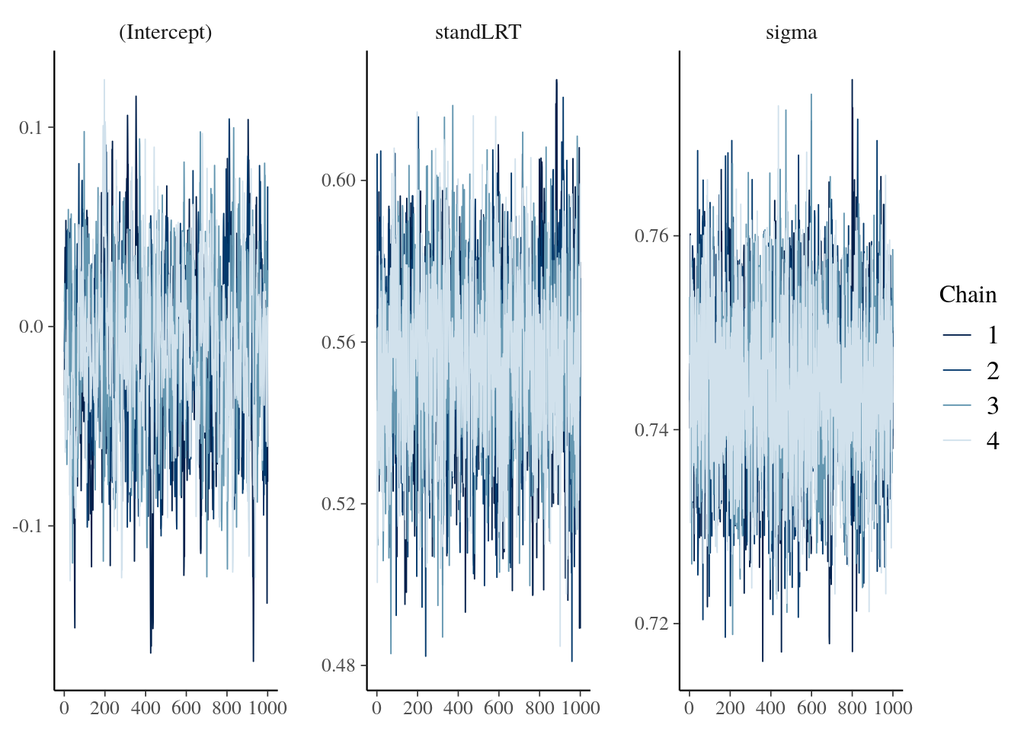

```r
plot(exam_hier, plotfun = "trace", pars = c("(Intercept)", "standLRT", "sigma"))
```

`stan_glmer()` uses the alternative parametrization, with an overall intercept and slope combined with group-specific differences from those. The first two trace plots above are for the so-called fixed effects. It’s impractical to look at the 65 additional pairs of trace plots, so later in the semester we will look at other ways of assessing convergence.

The posterior predictive check looks good—the blue simulated densities look quite similar to the black empirical density of the actual outcomes.

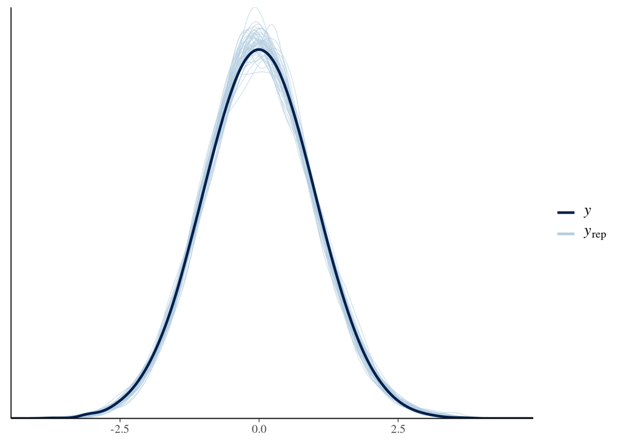

```r
pp_check(exam_hier)
```

## Results

To look at the densities of these same three parameters, we can use the following code. The default shaded region is the 50% equal tails credible interval.

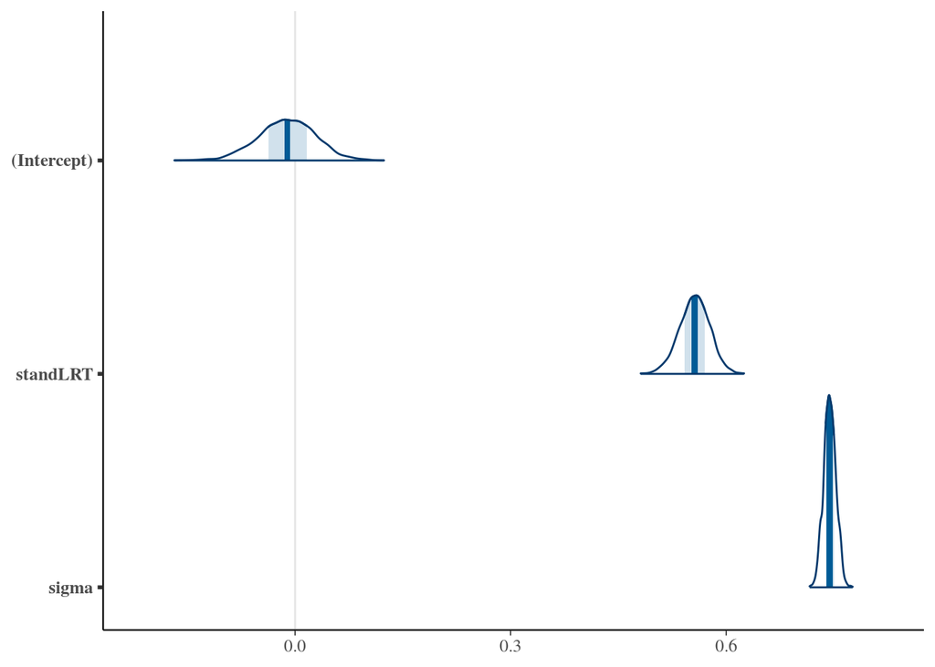

```r
plot(exam_hier, plotfun = "areas", pars = c("(Intercept)", "standLRT", "sigma"))
```

There are posteriors for the intercept effect and slope effect for each school. Remember, these effects are the differences from the overall intercept and slope. Here we see the distributions for all of the slope effects (you may need to zoom into the picture to see the detail). There is a faint line at x = 0 representing the average value. Ridges to the left of the line are below average and those to the right are above average. The code chunk will take a minute or two to run

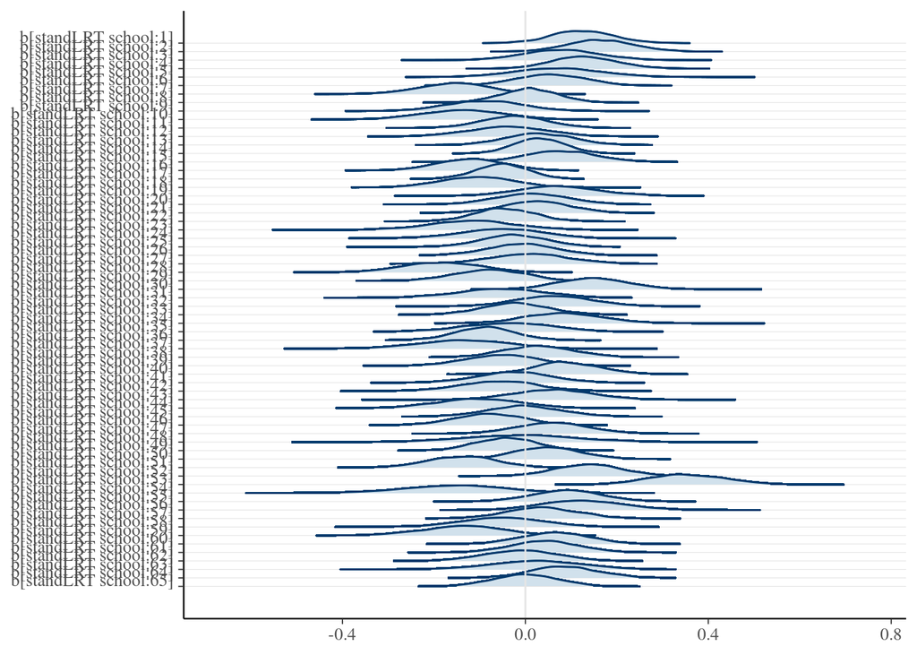

```r
plot(exam_hier, plotfun = "areas_ridges", regex_pars = "standLRT.+[1-9]")
```

```r
# the regex_pars argument is picking out the names of the group-specific slopes
```

I often find it helpful to look at the posterior two parameters at a time (but generally only the fixed effects parameters).

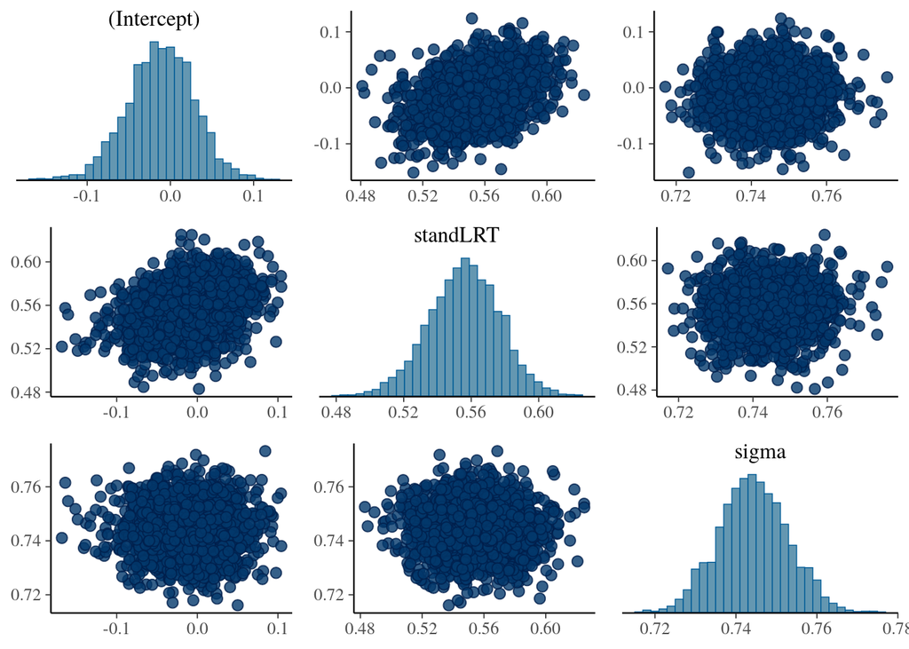

```r
plot(exam_hier, plotfun = "pairs", pars = c("(Intercept)", "standLRT", "sigma"))
```

You can get a very short summary by just typing the object name.

```r
exam_hier
```

```
## stan_glmer
##  family:       gaussian [identity]
##  formula:      normexam ~ standLRT + (standLRT | school)
##  observations: 4059
## ------
##             Median MAD_SD
## (Intercept) 0.0    0.0
## standLRT    0.6    0.0
##
## Auxiliary parameter(s):
##       Median MAD_SD
## sigma 0.7    0.0
##
## Error terms:
##  Groups   Name        Std.Dev. Corr
##  school   (Intercept) 0.31
##           standLRT    0.13     0.46
##  Residual             0.74
## Num. levels: school 65
##
## ------
## * For help interpreting the printed output see ?print.stanreg
## * For info on the priors used see ?prior_summary.stanreg
```

Although you can get a longer summary using the `summary()` function, I like the `model_parameters()` function. I use some of the function arguments to make some changes from the defaults. The credible interval is an highest density interval by default. We will learn what columns beyond the first three are.

```r
model_parameters(exam_hier, centrality = "mean", ci = .9)
```

```
## # Fixed effects
##
## Parameter   |  Mean |        90% CI |     pd | % in ROPE |  Rhat |     ESS |                      Prior
## -------------------------------------------------------------------------------------------------------
## (Intercept) | -0.01 | [-0.08, 0.05] | 60.10% |    98.30% | 1.006 |  531.11 | Normal (-1.14e-04 +- 2.50)
## standLRT    |  0.56 | [ 0.52, 0.59] |   100% |        0% | 1.000 | 1297.57 |      Normal (0.00 +- 2.51)
##
## # Fixed effects sigma
##
## Parameter | Mean |       90% CI |   pd | % in ROPE |  Rhat |     ESS |     Prior
## --------------------------------------------------------------------------------
## sigma     | 0.74 | [0.73, 0.76] | 100% |        0% | 0.999 | 5060.85 | NA ( +- )
```

By default, we get results for the fixed effects, which is usually what we want. We could get information on the posteriors for the group-specific effects by including a `effects = "random"` argument. Instead, the following plot uses a few tricks (that you don’t need to learn) to show the credible intervals for the school specific regression coefficients of `standLRT`. Notice that they are centered around 0; they do not include the overall `standLRT` regression coefficient.

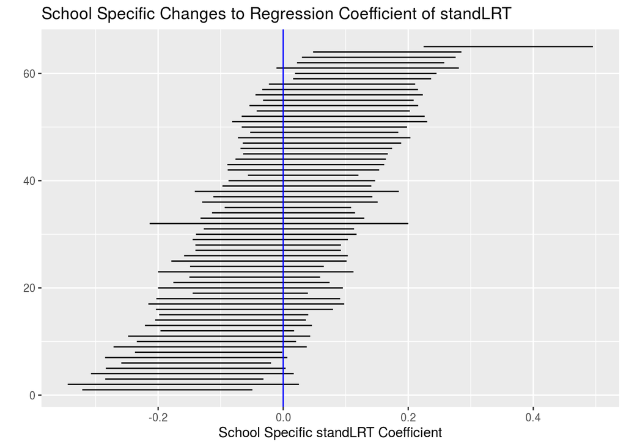

```r
posterior_interval(exam_hier, regex_pars = "b\\[standLRT") %>%
  as_tibble(rownames = "school") %>%
  mutate(midpoint = `5%` + `95%`,
         plot_order = rank(midpoint, ties.method = "random")) %>%
  ggplot(aes(
    y = plot_order,
    yend = plot_order,
    x = `5%`,
    xend = `95%`
  )) +
  geom_segment() +
  geom_vline(xintercept = 0, colour = "blue") +
  xlab("School Specific standLRT Coefficient") +
  ylab("") +
  ggtitle("School Specific Changes to Regression Coefficient of standLRT")
```